# MAE augmentation - Primary and secondary outcome definitions

Author

Laura Symul, Laura Vermeren

Published

July 2, 2026

```r
library(tidyverse)
library(magrittr)
library(gt)
library(patchwork)
library(SummarizedExperiment)
library(tidySummarizedExperiment)
library(MultiAssayExperiment)

tmp <- fs::dir_map("R scripts/", source)
tmp <- fs::dir_map("../VIBRANT-99-utils/R/", source)
rm(tmp)
theme_set(theme_light())
```

```r
mae_files <-
  fs::dir_ls(
    get_03_output_dir(),
    regexp = "mae_full_01_.*\\.rds$"
  ) |>
  sort(decreasing = TRUE) |>
  magrittr::extract(1)

mae <- readRDS(mae_files)

rm(mae_files)
```

The primary purpose of this document is to define and create additional assays to the `MultiAssayExperiment` object that contain the primary and secondary outcomes of the VIBRANT trial.

# Primary outcomes

## Primary outcome definition

The primary outcome is “colonization with any of the *L. crispatus* strains contained in the LBP by 5 weeks of follow-up as assessed by metagenomic sequencing of the vaginal microbial community with detection of any one of LBP strains at >5% relative abundance or a combination of the strains accounting for >10% relative abundance by metagenomics.”

## By metagenomics

### “LBP colonization” *at* each visit

We compute, at each visit and for each participant, the total relative abundance of all LBP strains or the maximum relative abundance of any LBP strain.

If the total relative abundance of all LBP strains is larger than 0.1 or the maximum relative abundance of any LBP strain is larger than 0.05, we consider that the LBP achieved colonization_mg *at* that visit.

```r
colonization_LBP_mg <-
  mae[["mg"]] |>
  as_tibble() |>
  dplyr::left_join(mae@colData |> as_tibble()) |>
  dplyr::filter(sample_type == "Clinical sample", !poor_quality_mg_data) |>
  dplyr::filter(!is.na(LBP)) |>
  group_by(.sample) |>
  summarize(
    n = n(),
    total_LBP_rel_ab_at = sum(rel_ab),
    max_LBP_rel_ab_at = max(rel_ab),
    n_detected_strains_at = sum(rel_ab > 0),
    n_detected_LC106_strains_at = sum(rel_ab[LBP == "LC106 & LC115"] > 0),
    n_detected_LC115_only_strains_at = sum(rel_ab[LBP == "LC115"] > 0)
  ) |>
  mutate(
    colonized_LBP_at_mg = (total_LBP_rel_ab_at > 0.1) |
      (max_LBP_rel_ab_at > 0.05)
  )
```

```r
colonization_LBP_mg <-
  colonization_LBP_mg |>
  dplyr::left_join(
    mae@colData |>
      as_tibble() |>
      select(uid, pid, visit_code, randomized, arm, location) |>
      dplyr::rename(.sample = uid),
    by = join_by(.sample)
  ) |>
  arrange(pid, visit_code)
```

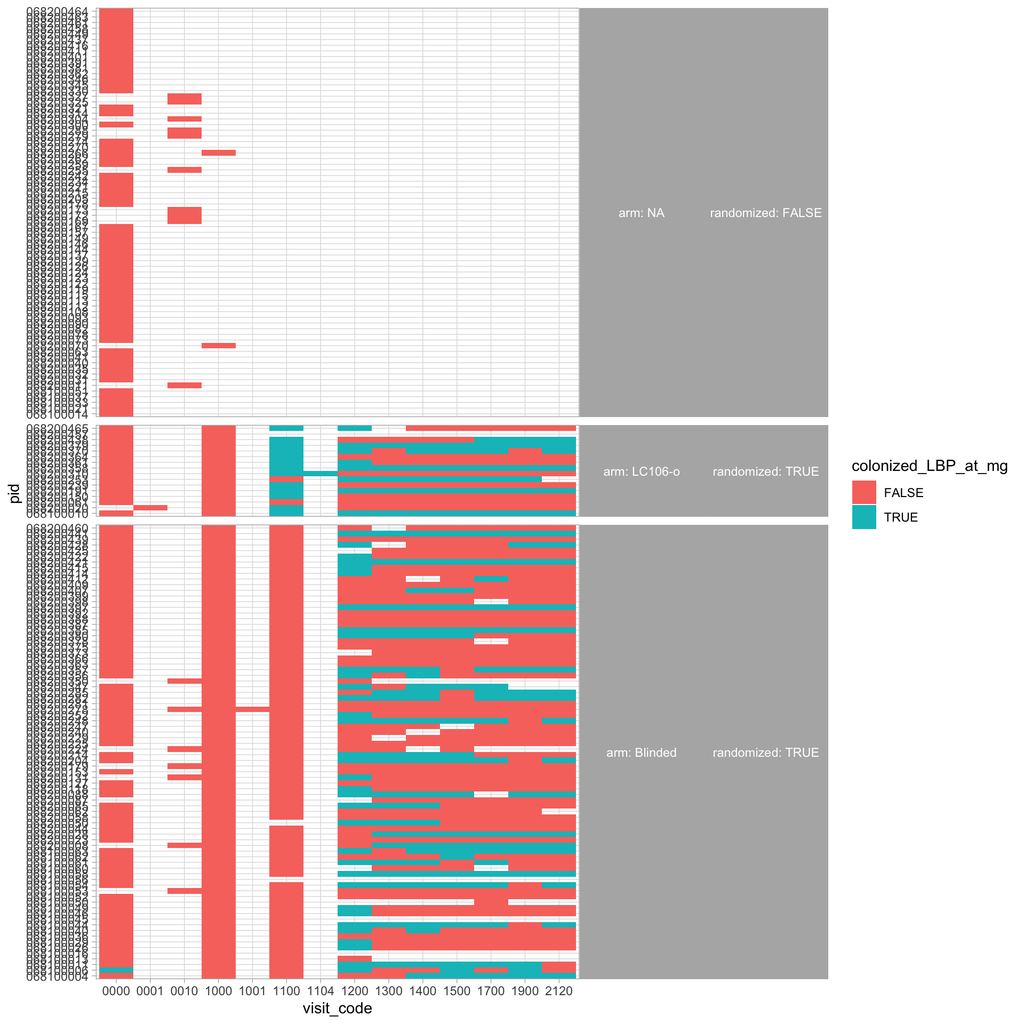

```r
colonization_LBP_mg |>
  ggplot() +
  aes(x = visit_code, y = pid, fill = colonized_LBP_at_mg) +
  geom_tile() +
  facet_grid(
    randomized + arm ~ .,
    scales = "free_y",
    space = "free_y",
    labeller = label_both
  ) +
  theme(
    strip.text.y = element_text(angle = 0)
  )
```

### “LBP colonization” *by* each visit

From the colonization_mg status at each visit, we can compute the colonization_mg status *by* each visit.

A participant is considered to have colonized *by* a visit if they have been colonized at that visit or any previous visit, starting from their post-product visit (“1200” for all groups).

Since we have some missing visits, we impute these as “not colonized”

```r
colonization_LBP_mg <-
  colonization_LBP_mg |>
  select(-c(arm, randomized, location)) |>
  dplyr::full_join(
    colonization_LBP_mg |>
      select(pid, arm, randomized, location) |>
      distinct() |>
      expand_grid(
        visit_code = unique(colonization_LBP_mg$visit_code) |> sort()
      ),
    by = join_by(pid, visit_code)
  )
```

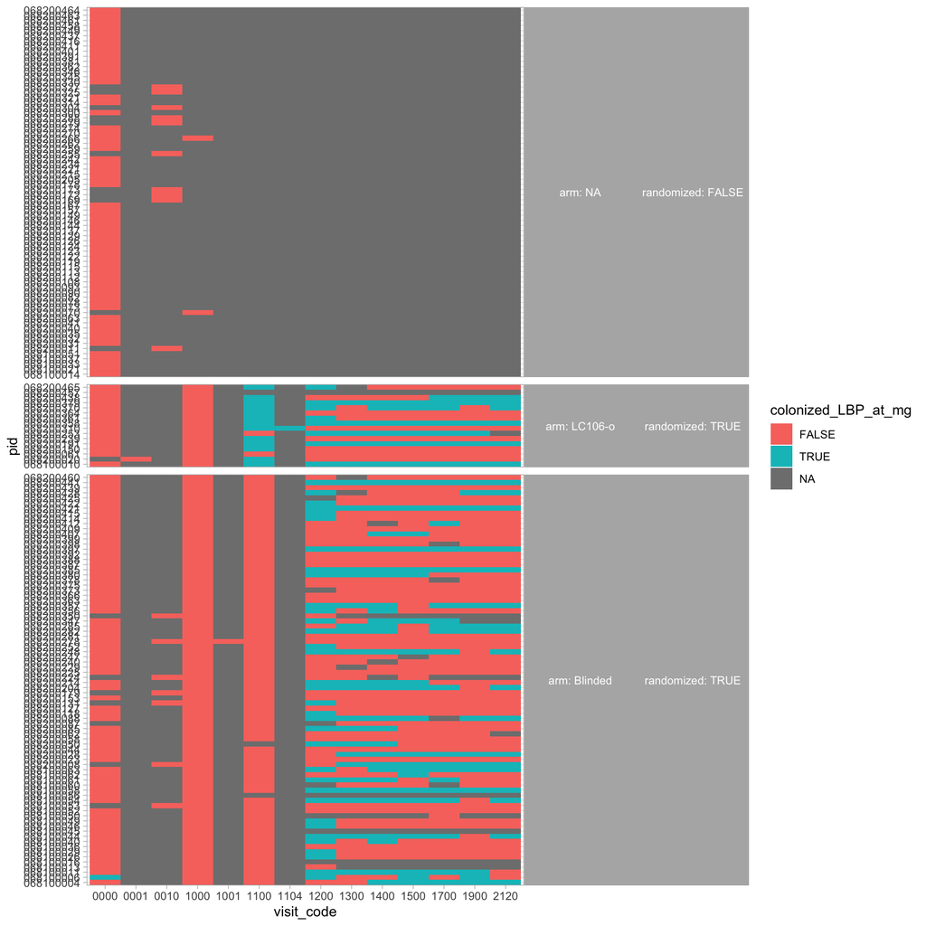

```r
colonization_LBP_mg |>
  ggplot() +
  aes(x = visit_code, y = pid, fill = colonized_LBP_at_mg) +
  geom_tile() +
  facet_grid(
    randomized + arm ~ .,
    scales = "free_y",
    space = "free_y",
    labeller = label_both
  ) +
  theme(
    strip.text.y = element_text(angle = 0)
  )
```

```r
colonization_LBP_mg <-
  colonization_LBP_mg |>
  mutate(colonized_LBP_at_mg = colonized_LBP_at_mg |> replace_na(FALSE)) |>
  arrange(pid, visit_code) |>
  group_by(pid) |>
  mutate(
    tmp = ifelse(as.numeric(visit_code) < 1200, FALSE, colonized_LBP_at_mg),
    colonized_LBP_by_mg = cummax(tmp) |> as.logical()
  ) |>
  ungroup() |>
  select(-tmp)
```

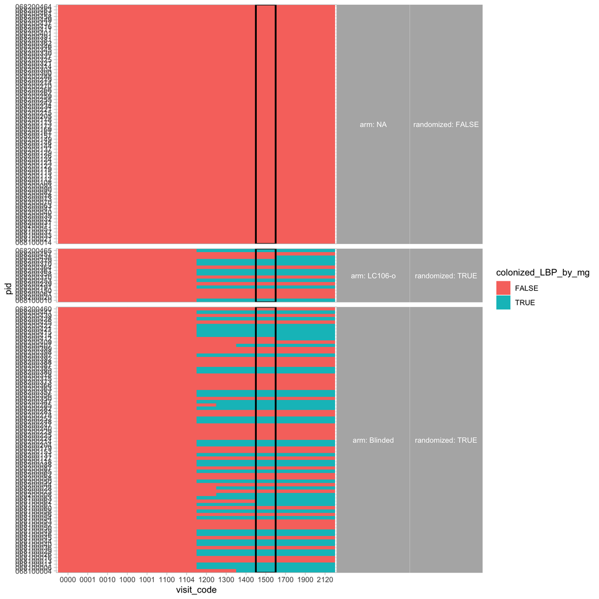

```r
colonization_LBP_mg |>
  ggplot() +
  aes(x = visit_code, y = pid, fill = colonized_LBP_by_mg) +
  geom_tile() +
  annotate(
    geom = "rect",
    xmin = 10.5,
    xmax = 11.5,
    ymin = -Inf,
    ymax = Inf,
    col = "black",
    alpha = 0,
    linewidth = 1
  ) +
  facet_grid(
    randomized + arm ~ .,
    scales = "free_y",
    space = "free_y",
    labeller = label_both
  ) +
  theme(
    strip.text.y = element_text(angle = 0)
  )
```

### “*L. crispatus* colonization” *at* each visit

We compute, at each visit and for each participant, the total relative abundance of *L. crispatus*.

If the total relative abundance of *L. crispatus* strains is larger than 50%, we consider that the participant’s VM was colonized by *L. crispatus* *at* that visit.

```r
colonization_crispatus_mg <-
  mae[["mg"]] |>
  as_tibble() |>
  dplyr::left_join(mae@colData |> as_tibble()) |>
  dplyr::filter(sample_type == "Clinical sample", !poor_quality_mg_data) |>
  dplyr::filter(species == "crispatus") |>
  group_by(.sample) |>
  summarize(
    total_crispatus_rel_ab_at = sum(rel_ab),
  ) |>
  mutate(
    crispatus_dominance_at_mg = (total_crispatus_rel_ab_at >= 0.5)
  )
```

```r
colonization_crispatus_mg <-
  colonization_crispatus_mg |>
  dplyr::left_join(
    mae@colData |>
      as_tibble() |>
      select(uid, pid, visit_code, randomized, arm, location) |>
      dplyr::rename(.sample = uid),
    by = join_by(.sample)
  ) |>
  arrange(pid, visit_code)
```

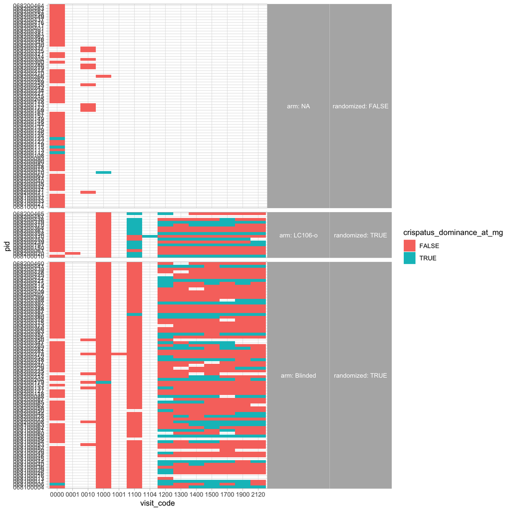

```r
colonization_crispatus_mg |>
  ggplot() +
  aes(x = visit_code, y = pid, fill = crispatus_dominance_at_mg) +
  geom_tile() +
  facet_grid(
    randomized + arm ~ .,
    scales = "free_y",
    space = "free_y",
    labeller = label_both
  ) +
  theme(
    strip.text.y = element_text(angle = 0)
  )
```

### “Crispatus colonization” *by* each visit

From the colonization_mg status at each visit, we can compute the colonization_mg status *by* each visit.

A participant is considered to have colonized *by* a visit if they have been colonized at that visit or any previous visit, starting from their post-product visit (“1200” for all groups).

Since we have some missing visits, we impute these as “not colonized”

```r
colonization_crispatus_mg <-
  colonization_crispatus_mg |>
  select(-c(arm, randomized, location)) |>
  dplyr::full_join(
    colonization_crispatus_mg |>
      select(pid, arm, randomized, location) |>
      distinct() |>
      expand_grid(
        visit_code = unique(colonization_crispatus_mg$visit_code) |> sort()
      ),
    by = join_by(pid, visit_code)
  )
```

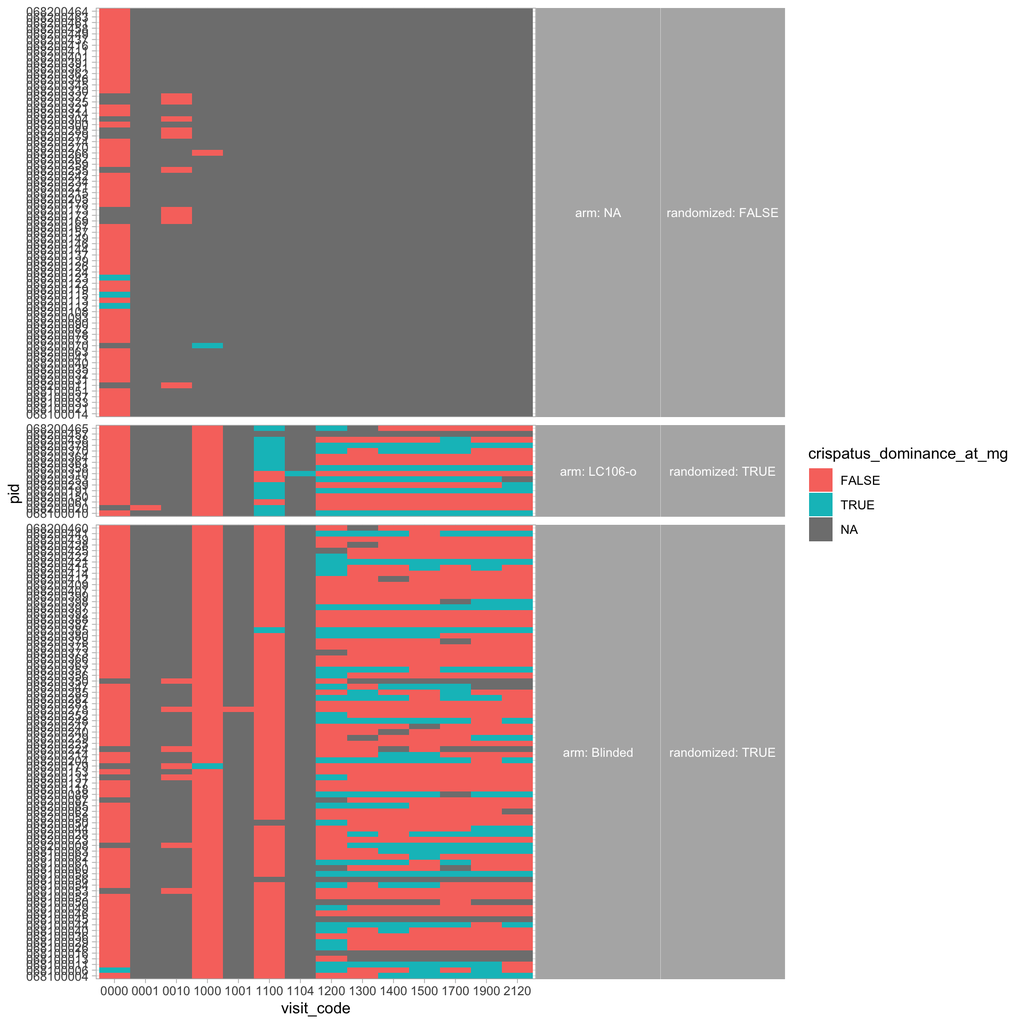

```r
colonization_crispatus_mg |>
  ggplot() +
  aes(x = visit_code, y = pid, fill = crispatus_dominance_at_mg) +
  geom_tile() +
  facet_grid(
    randomized + arm ~ .,
    scales = "free_y",
    space = "free_y",
    labeller = label_both
  ) +
  theme(
    strip.text.y = element_text(angle = 0)
  )
```

```r
colonization_crispatus_mg <-
  colonization_crispatus_mg |>
  arrange(pid, visit_code) |>
  mutate(
    crispatus_dominance_at_mg = crispatus_dominance_at_mg |> replace_na(FALSE)
  ) |>
  group_by(pid) |>
  mutate(
    tmp = ifelse(
      as.numeric(visit_code) < 1200,
      FALSE,
      crispatus_dominance_at_mg
    ),
    crispatus_dominance_by_mg = cummax(tmp) |> as.logical()
  ) |>
  ungroup() #|>
#select(-tmp)
```

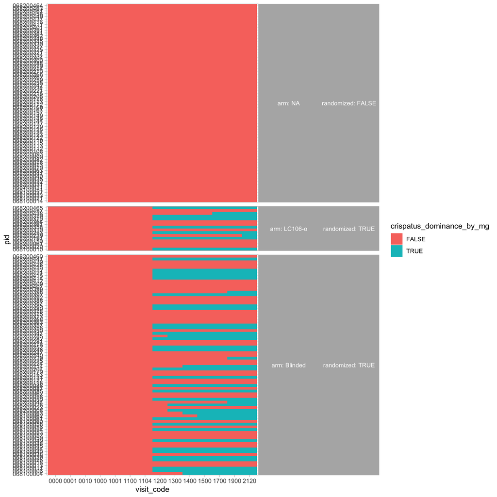

```r
colonization_crispatus_mg |>
  ggplot() +
  aes(x = visit_code, y = pid, fill = crispatus_dominance_by_mg) +
  geom_tile() +
  facet_grid(
    randomized + arm ~ .,
    scales = "free_y",
    space = "free_y",
    labeller = label_both
  ) +
  theme(
    strip.text.y = element_text(angle = 0)
  )
```

### LBP colonization VS crispatus dominance

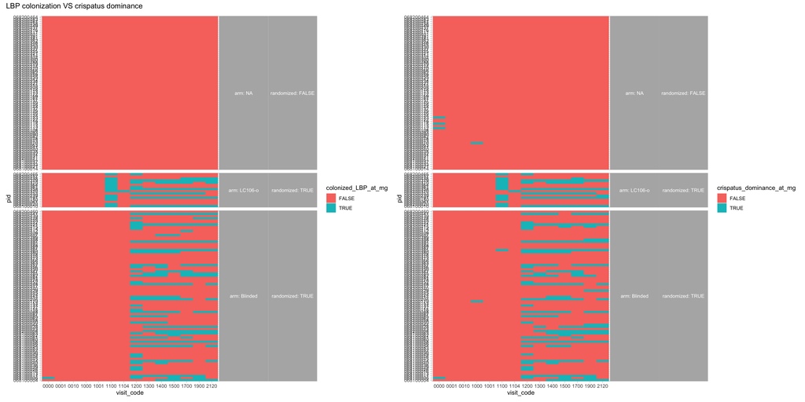

```r
p1 <- colonization_LBP_mg |>
  ggplot() +
  aes(x = visit_code, y = pid, fill = colonized_LBP_at_mg) +
  geom_tile() +
  facet_grid(
    randomized + arm ~ .,
    scales = "free_y",
    space = "free_y",
    labeller = label_both
  ) +
  theme(
    strip.text.y = element_text(angle = 0)
  )

p2 <- colonization_crispatus_mg |>
  ggplot() +
  aes(x = visit_code, y = pid, fill = crispatus_dominance_at_mg) +
  geom_tile() +
  facet_grid(
    randomized + arm ~ .,
    scales = "free_y",
    space = "free_y",
    labeller = label_both
  ) +
  theme(
    strip.text.y = element_text(angle = 0)
  )

p1 +
  p2 +
  plot_annotation(
    title = str_c("LBP colonization VS crispatus dominance")
  ) +
  plot_layout(ncol = 2) &
  theme(
    legend.justification = "left"
  )
```

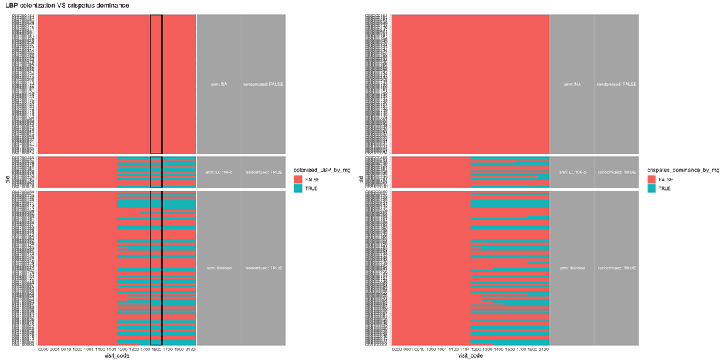

```r
p1 <- colonization_LBP_mg |>
  ggplot() +
  aes(x = visit_code, y = pid, fill = colonized_LBP_by_mg) +
  geom_tile() +
  annotate(
    geom = "rect",
    xmin = 10.5,
    xmax = 11.5,
    ymin = -Inf,
    ymax = Inf,
    col = "black",
    alpha = 0,
    linewidth = 1
  ) +
  facet_grid(
    randomized + arm ~ .,
    scales = "free_y",
    space = "free_y",
    labeller = label_both
  ) +
  theme(
    strip.text.y = element_text(angle = 0)
  )

p2 <- colonization_crispatus_mg |>
  ggplot() +
  aes(x = visit_code, y = pid, fill = crispatus_dominance_by_mg) +
  geom_tile() +
  facet_grid(
    randomized + arm ~ .,
    scales = "free_y",
    space = "free_y",
    labeller = label_both
  ) +
  theme(
    strip.text.y = element_text(angle = 0)
  )

p1 +
  p2 +
  plot_annotation(
    title = str_c("LBP colonization VS crispatus dominance")
  ) +
  plot_layout(ncol = 2) &
  theme(
    legend.justification = "left"
  )
```

## By qPCR

### “LBP colonization” *at* each visit

We compute, at each visit and for each participant, the relative abundance of each LBP strain as estimated by qPCR by dividing the copies per swab for that strain by the copies per swab for the 16S rRNA gene.

Then, just as we did for the metagenomics, we compute the total relative abundance of all LBP strains or the maximum relative abundance of any LBP strain.

If the total relative abundance of all LBP strains is larger than 0.1 or the maximum relative abundance of any LBP strain is larger than 0.05, we consider that the LBP achieved colonization *at* that visit by qPCR.

```r
colonization_qPCR <-
  mae[["qPCR"]] |>
  as_tibble() |>
  left_join(mae@colData |> as_tibble()) |>
  dplyr::filter(sample_type == "Clinical sample") |>
  dplyr::filter(!is.na(LBP)) |>
  # we add the 16S copies per swab to compute the relative abundance
  left_join(
    mae[["qPCR"]] |>
      as_tibble() |>
      left_join(mae@colData |> as_tibble()) |>
      dplyr::filter(sample_type == "Clinical sample") |>
      dplyr::filter(is.na(LBP), .feature == "16S") |>
      select(.sample, copies_per_swab_med_corrected) |> #copies_per_swab_med
      dplyr::rename(copies_per_swab_16S = copies_per_swab_med_corrected), # copies_per_swab_med
    by = join_by(.sample)
  ) |>
  mutate(rel_ab = copies_per_swab_med_corrected / copies_per_swab_16S) |> #copies_per_swab_16S
  select(
    .feature,
    .sample,
    rel_ab,
    copies_per_swab_med_corrected,
    copies_per_swab_16S,
    everything()
  ) |> #copies_per_swab_16S
  group_by(.sample) |>
  summarize(
    total_LBP_rel_ab_at = sum(rel_ab),
    max_LBP_rel_ab_at = max(rel_ab),
    n_detected_strains_at = sum(copies_per_swab_med > 0),
    n_detected_LC106_strains_at = sum(
      copies_per_swab_med[LBP == "LC106 & LC115"] > 0
    ),
    n_detected_LC115_only_strains_at = sum(
      copies_per_swab_med[LBP == "LC115"] > 0
    )
  ) |>
  mutate(
    colonized_LBP_at_qpcr = (total_LBP_rel_ab_at > 0.1) |
      (max_LBP_rel_ab_at > 0.05),
    LBP_detected_at_qpcr = (n_detected_strains_at > 2)
  )
```

```r
colonization_qPCR <-
  colonization_qPCR |>
  dplyr::left_join(
    mae@colData |>
      as_tibble() |>
      select(uid, pid, visit_code, randomized, arm, location) |>
      dplyr::rename(.sample = uid),
    by = join_by(.sample)
  ) |>
  arrange(pid, visit_code)
```

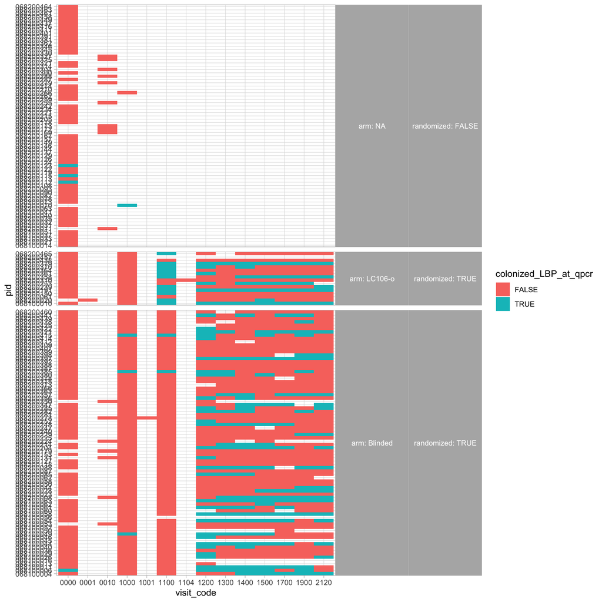

```r
colonization_qPCR |>
  ggplot() +
  aes(x = visit_code, y = pid, fill = colonized_LBP_at_qpcr) +
  geom_tile() +
  facet_grid(
    randomized + arm ~ .,
    scales = "free_y",
    space = "free_y",
    labeller = label_both
  ) +
  theme(
    strip.text.y = element_text(angle = 0)
  )
```

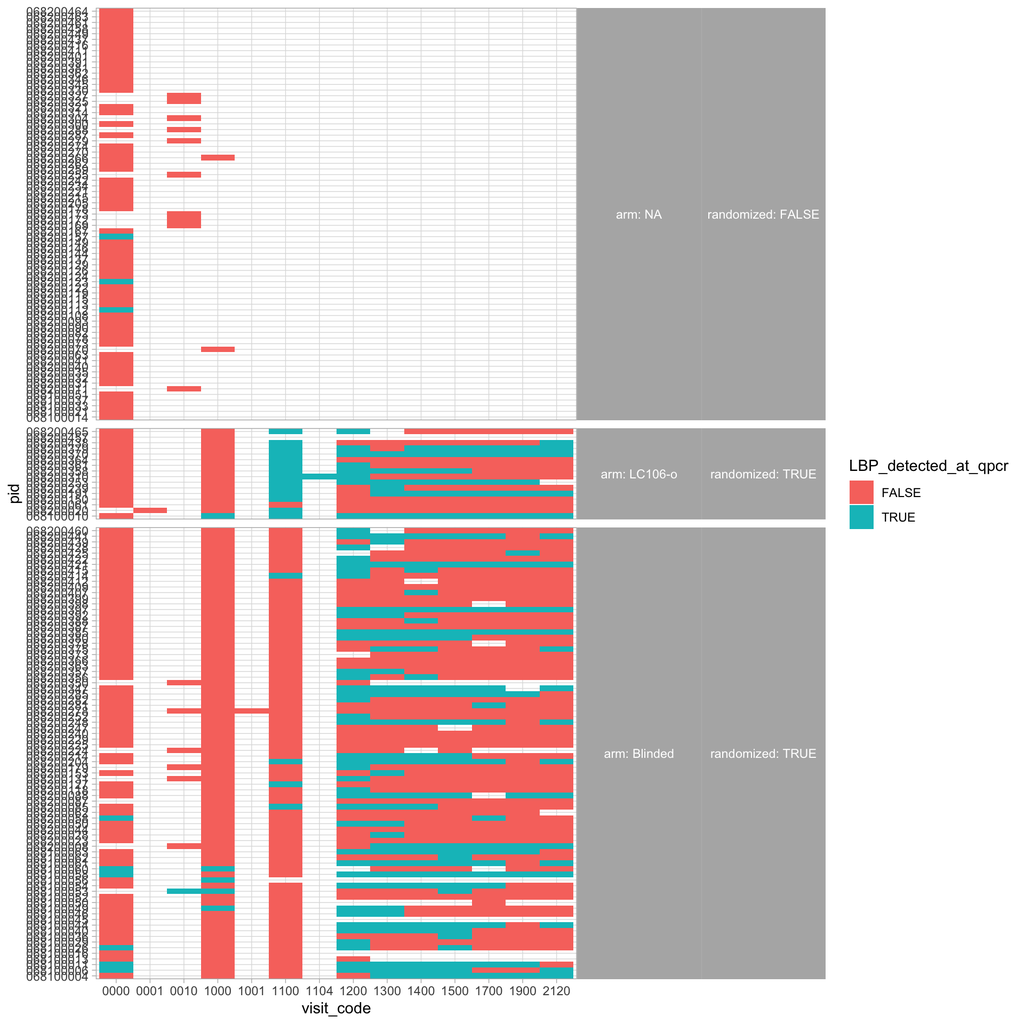

```r
colonization_qPCR |>
  ggplot() +
  aes(x = visit_code, y = pid, fill = LBP_detected_at_qpcr) +
  geom_tile() +
  facet_grid(
    randomized + arm ~ .,
    scales = "free_y",
    space = "free_y",
    labeller = label_both
  ) +
  theme(
    strip.text.y = element_text(angle = 0)
  )
```

### “LBP colonization” *by* each visit

From the colonization status at each visit, we can compute the colonization status *by* each visit.

A participant is considered to have colonized *by* a visit if they have been colonized at that visit or any previous visit, starting from their post-product visit (“1200” for all groups).

Since we have some missing visits, we impute these as “not colonized”

```r
colonization_qPCR <-
  colonization_qPCR |>
  select(-c(arm, randomized, location)) |>
  dplyr::full_join(
    colonization_qPCR |>
      select(pid, arm, randomized, location) |>
      distinct() |>
      expand_grid(
        visit_code = unique(colonization_qPCR$visit_code) |> sort()
      ),
    by = join_by(pid, visit_code)
  )
```

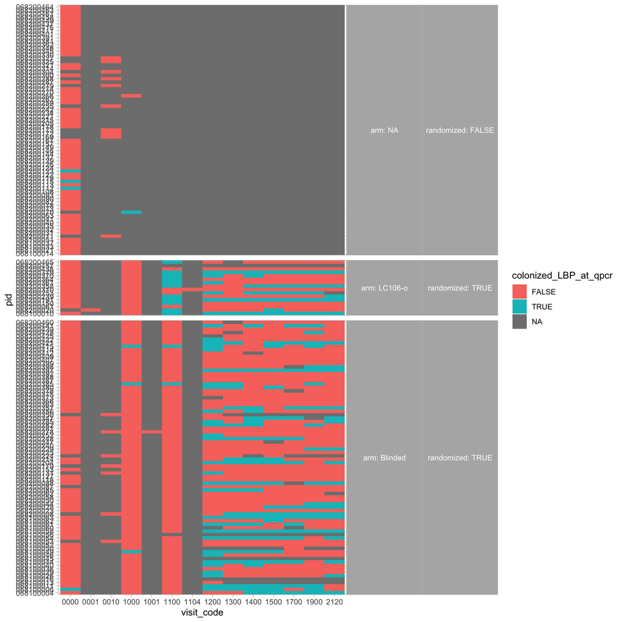

```r
colonization_qPCR |>
  ggplot() +
  aes(x = visit_code, y = pid, fill = colonized_LBP_at_qpcr) +
  geom_tile() +
  facet_grid(
    randomized + arm ~ .,
    scales = "free_y",
    space = "free_y",
    labeller = label_both
  ) +
  theme(
    strip.text.y = element_text(angle = 0)
  )
```

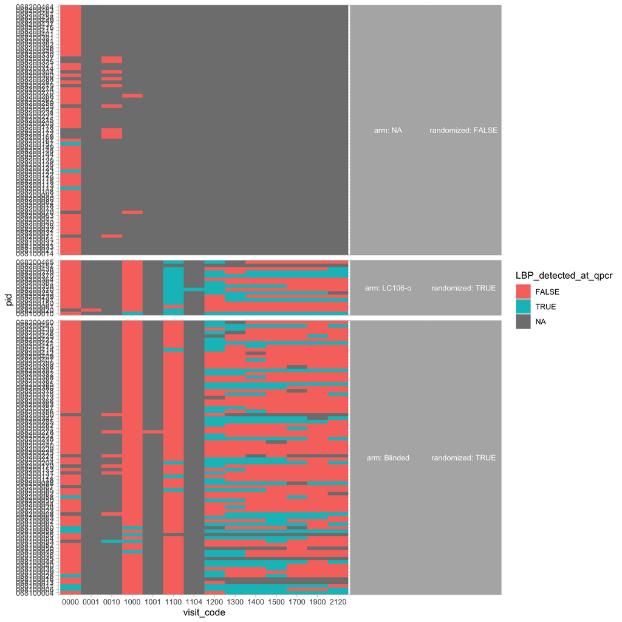

```r
colonization_qPCR |>
  ggplot() +
  aes(x = visit_code, y = pid, fill = LBP_detected_at_qpcr) +
  geom_tile() +
  facet_grid(
    randomized + arm ~ .,
    scales = "free_y",
    space = "free_y",
    labeller = label_both
  ) +
  theme(
    strip.text.y = element_text(angle = 0)
  )
```

```r
colonization_qPCR <-
  colonization_qPCR |>
  arrange(pid, visit_code) |>
  mutate(
    colonized_LBP_at_qpcr = colonized_LBP_at_qpcr |> replace_na(FALSE),
    LBP_detected_at_qpcr = LBP_detected_at_qpcr |> replace_na(FALSE)
  ) |>
  group_by(pid) |>
  mutate(
    tmp = ifelse(as.numeric(visit_code) < 1200, FALSE, colonized_LBP_at_qpcr),
    colonized_LBP_by_qpcr = cummax(tmp) |> as.logical(),
    tmp = ifelse(as.numeric(visit_code) < 1200, FALSE, LBP_detected_at_qpcr),
    LBP_detected_by_qpcr = cummax(tmp) |> as.logical()
  ) |>
  ungroup() |>
  select(-tmp)
```

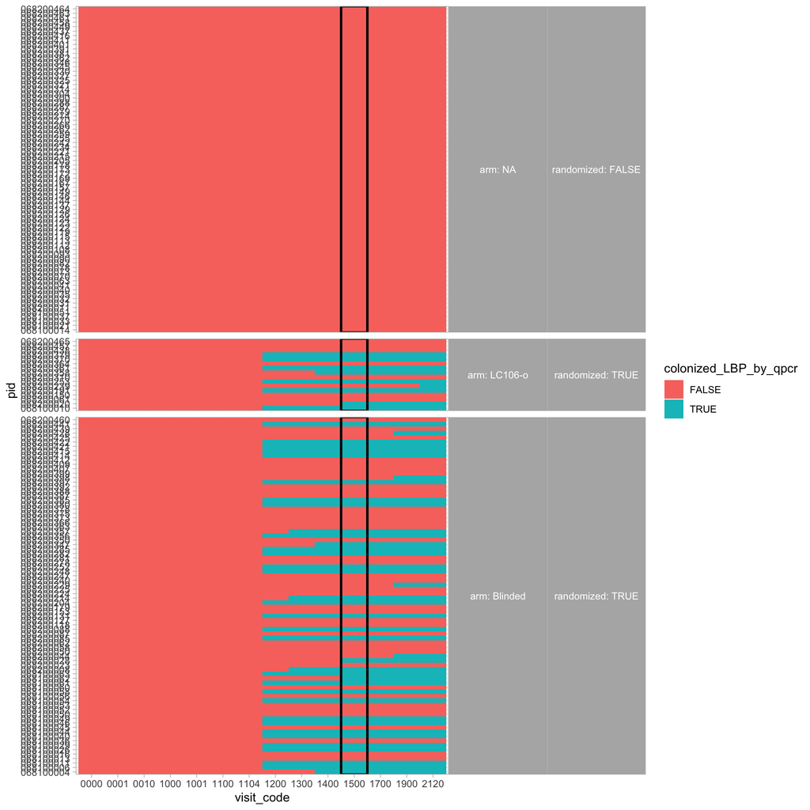

```r
colonization_qPCR |>
  ggplot() +
  aes(x = visit_code, y = pid, fill = colonized_LBP_by_qpcr) +
  geom_tile() +
  annotate(
    geom = "rect",
    xmin = 10.5,
    xmax = 11.5,
    ymin = -Inf,
    ymax = Inf,
    col = "black",
    alpha = 0,
    linewidth = 1
  ) +
  facet_grid(
    randomized + arm ~ .,
    scales = "free_y",
    space = "free_y",
    labeller = label_both
  ) +
  theme(
    strip.text.y = element_text(angle = 0)
  )
```

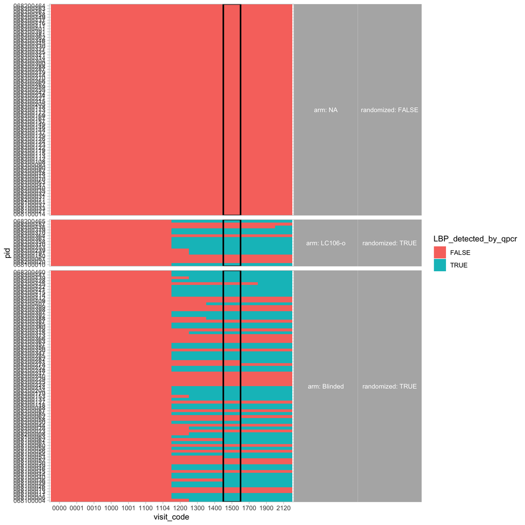

```r
colonization_qPCR |>
  ggplot() +
  aes(x = visit_code, y = pid, fill = LBP_detected_by_qpcr) +
  geom_tile() +
  annotate(
    geom = "rect",
    xmin = 10.5,
    xmax = 11.5,
    ymin = -Inf,
    ymax = Inf,
    col = "black",
    alpha = 0,
    linewidth = 1
  ) +
  facet_grid(
    randomized + arm ~ .,
    scales = "free_y",
    space = "free_y",
    labeller = label_both
  ) +
  theme(
    strip.text.y = element_text(angle = 0)
  )
```

### Colonization qPCR VS metagenomics

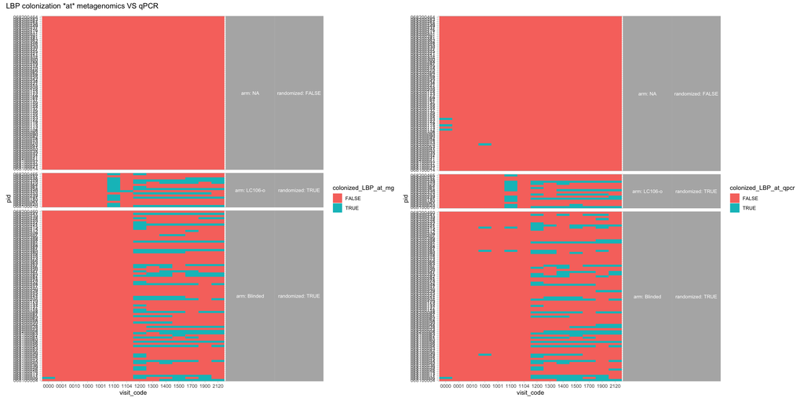

```r
p1 <- colonization_LBP_mg |>
  ggplot() +
  aes(x = visit_code, y = pid, fill = colonized_LBP_at_mg) +
  geom_tile() +
  facet_grid(
    randomized + arm ~ .,
    scales = "free_y",
    space = "free_y",
    labeller = label_both
  ) +
  theme(
    strip.text.y = element_text(angle = 0)
  )

p2 <- colonization_qPCR |>
  ggplot() +
  aes(x = visit_code, y = pid, fill = colonized_LBP_at_qpcr) +
  geom_tile() +
  facet_grid(
    randomized + arm ~ .,
    scales = "free_y",
    space = "free_y",
    labeller = label_both
  ) +
  theme(
    strip.text.y = element_text(angle = 0)
  )

p1 +
  p2 +
  plot_annotation(
    title = str_c("LBP colonization *at* metagenomics VS qPCR")
  ) +
  plot_layout(ncol = 2) &
  theme(
    legend.justification = "left"
  )
```

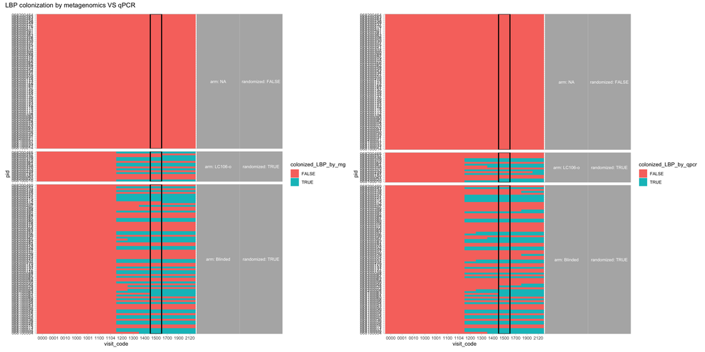

```r
p1 <- colonization_LBP_mg |>
  ggplot() +
  aes(x = visit_code, y = pid, fill = colonized_LBP_by_mg) +
  geom_tile() +
  annotate(
    geom = "rect",
    xmin = 10.5,
    xmax = 11.5,
    ymin = -Inf,
    ymax = Inf,
    col = "black",
    alpha = 0,
    linewidth = 1
  ) +
  facet_grid(
    randomized + arm ~ .,
    scales = "free_y",
    space = "free_y",
    labeller = label_both
  ) +
  theme(
    strip.text.y = element_text(angle = 0)
  )


p2 <- colonization_qPCR |>
  ggplot() +
  aes(x = visit_code, y = pid, fill = colonized_LBP_by_qpcr) +
  geom_tile() +
  annotate(
    geom = "rect",
    xmin = 10.5,
    xmax = 11.5,
    ymin = -Inf,
    ymax = Inf,
    col = "black",
    alpha = 0,
    linewidth = 1
  ) +
  facet_grid(
    randomized + arm ~ .,
    scales = "free_y",
    space = "free_y",
    labeller = label_both
  ) +
  theme(
    strip.text.y = element_text(angle = 0)
  )

p1 +
  p2 +
  plot_annotation(
    title = str_c("LBP colonization by metagenomics VS qPCR")
  ) +
  plot_layout(ncol = 2) &
  theme(
    legend.justification = "left"
  )
```

## Adding `primary_outcomes` assay to `MAE`

```r
se_primary_col_LBP_mg <-
  SummarizedExperiment(
    assays = list(
      outcome = colonization_LBP_mg |>
        # filter(!is.na(pid)) |>
        # mutate(.sample = str_c(pid, "_", visit_code)) |>
        dplyr::filter(!is.na(.sample)) |>
        select(.sample, colonized_LBP_at_mg, colonized_LBP_by_mg) |>
        as.data.frame() |>
        column_to_rownames(".sample") |>
        t()
    )
  )

se_primary_col_crisp_mg <-
  SummarizedExperiment(
    assays = list(
      outcome = colonization_crispatus_mg |>
        dplyr::filter(!is.na(.sample)) |>
        select(.sample, crispatus_dominance_at_mg, crispatus_dominance_by_mg) |>
        as.data.frame() |>
        column_to_rownames(".sample") |>
        t()
    )
  )

se_primary_col_LBP_qPCR <-
  SummarizedExperiment(
    assays = list(
      outcome = colonization_qPCR |>
        dplyr::filter(!is.na(.sample)) |>
        select(
          .sample,
          colonized_LBP_at_qpcr,
          colonized_LBP_by_qpcr,
          LBP_detected_at_qpcr,
          LBP_detected_by_qpcr
        ) |>
        as.data.frame() |>
        column_to_rownames(".sample") |>
        t()
    )
  )


mae <- c(
  mae,
  list(
    col_LBP_mg = se_primary_col_LBP_mg,
    col_crispatus_mg = se_primary_col_crisp_mg,
    col_LBP_qPCR = se_primary_col_LBP_qPCR
  )
)
```

# Saving the `MultiAssayExperiment` objects

We save the MAE for downstream analyses.

```r
saveRDS(
  mae,
  str_c(
    get_03_output_dir(),
    "mae_full_02_",
    today() |> str_remove_all("-"),
    ".rds"
  )
)
```